# Mapping in R - selected exercises

## Task 1: Make a map by state

**Task**: Aggregate the number of headquarters by state. Make a map in which the states are shaded by their number of Fortune 500 companies

Use `dplyr()` for the aggregation and the `maps()` package for a map of the U.S. with state boundaries.

```r
# Number of companies in each state
fortune_500_states <- fortune500 %>%
  group_by(state) %>%
  summarise("Number of Companies" = n())
```

```r
#Generate states map file
states_map <- get_urbn_map("states")
fortune_500_states_4plot <- states_map %>%
  left_join(fortune_500_states, by = c("state_name" = "state"))

# Replace NAs with 0
fortune_500_states_4plot$`Number of Companies` <-
  replace_na(fortune_500_states_4plot$`Number of Companies`, 0)

# Get state centroids
state_centroids <- data.frame(state = state.abb,
                              centroid_x = state.center$x,
                              centroid_y = state.center$y,
                              stringsAsFactors = FALSE)

# Change Alaska's centroid
state_centroids$centroid_x[[2]] <- -116.8510
state_centroids$centroid_y[[2]] <- 27.3

# Change Hawaii's centroid
state_centroids$centroid_x[[11]] <- -104.9420
state_centroids$centroid_y[[11]] <- 26
```

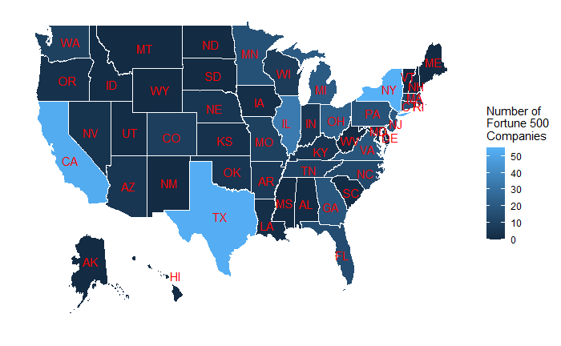

```r
ggplot(fortune_500_states_4plot) +
  geom_polygon(aes(x = .data$long,
                   y = .data$lat,
                   group = .data$group,
                   fill = .data$`Number of Companies`),
               colour = "white") +
  scale_fill_continuous(name = "Number of\nFortune 500\nCompanies") +
  geom_text(data = state_centroids,
                  inherit.aes = FALSE,
                  aes(x = centroid_x, y = centroid_y, label = state), colour = "red") +
  theme(axis.title.x = element_blank(),
        axis.title.y = element_blank(),
        axis.text.x = element_blank(),
        axis.text.y = element_blank(),
        axis.line.x = element_blank(),
        axis.line.y = element_blank(),
        axis.ticks.x = element_blank(),
        axis.ticks.y = element_blank(),
        panel.background = element_blank())
```

## Task 2: Tax Rates by State

**Task**: We also got some info on top corporate income tax rates by state. Import sheet 2 of the file `State_Corporate_Income_Tax_Rates_2015.xlsx` and make a map shaded by top corporate income tax rates.

```r
top_corp_Y_tax <- read_excel("State_Corporate_Income_Tax_Rates_2015.xlsx",
                sheet = "topcorptax")
top_corp_Y_tax$state[[51]] <- "District of Columbia"

fortune_500_states_4plot <- left_join(fortune_500_states_4plot,
                                      top_corp_Y_tax, by = c("state_name" = "state"))
```

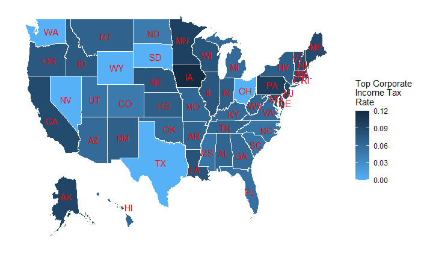

```r
ggplot(fortune_500_states_4plot) +
  geom_polygon(aes(x = .data$long,
                   y = .data$lat,
                   group = .data$group,
                   fill = .data$topcorpinctax),
               colour = "white") +
  scale_fill_continuous(name = "Top Corporate\nIncome Tax\nRate",
                        low = "#56B1F7",
                        high = "#132B43") +
  geom_text(data = state_centroids,
                  inherit.aes = FALSE,
                  aes(x = centroid_x, y = centroid_y, label = state), colour = "red") +
  theme(axis.title.x = element_blank(),
        axis.title.y = element_blank(),
        axis.text.x = element_blank(),
        axis.text.y = element_blank(),
        axis.line.x = element_blank(),
        axis.line.y = element_blank(),
        axis.ticks.x = element_blank(),
        axis.ticks.y = element_blank(),
        panel.background = element_blank())
```